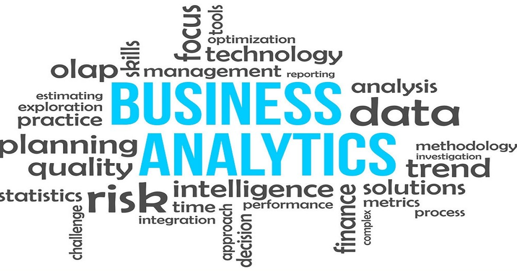

# REPORT : CUSTOMER LIFETIME VALUE PREDICTION

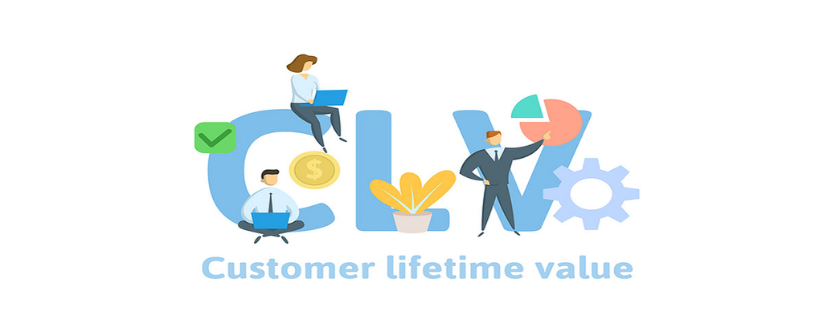

### TEAM NO.2 :

MERIN GEORGE

ANJU MARIA RAJU

AADHYA SHARMA

CHANDAN J R

RANJITH KUMAR K.N

MARIYA BIJU

### PROBLEM STATEMENT / AIM

The objective of this project is the prediction of Customer Life-time Value (CLV). CLV is the lifetime value of a customer, or in other words it represents the total amount of money a customer is expected to spend in business, or on products, during their lifetime. CLV is an important metric because it provides the business groups with a customer-centric perspective to guide some critical marketing and sales strategies, thereby enhancing important business decisions.

### WORKFLOW:

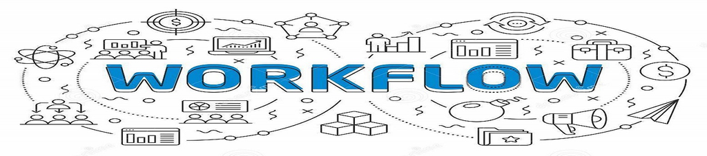

Initially in this project we have analysed the data through various exploratory data analysis techniques to explain the relationship between Customer Lifetime Value that is the target variable with the other explanatory variables. Further after rigorous analysis the most appropriate model is chosen and fitted to the data, which provides the highest accuracy.

### UNDERSTANDING THE DATA

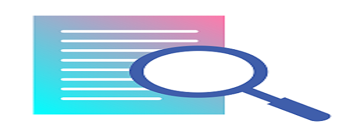

1. Data columns and values: There are a total of 24 data columns including the target variable that is the CLV. The columns are Customer, State , CLV , Response, Coverage, Education, EffectiveToDate, EmploymentStatus, Gender, Income, LocationCode ,MaritalStatus, MonthlyPremiumAuto , MonthsSinceLastClaim, MonthsSincePolicyInception, NumberofOpenComplaints, NumberofPolicies, PolicyType, Policy , RenewOfferType, SalesChannel , TotalClaimAmount , VehicleClass and VehicleSize. There are a total of 9134 Observations in the dataset.
2. The dataset consists of a blend of both categorical and numeric columns: The categorical columns are : Customer, State , Response, Coverage, Education, EffectiveToDate, EmploymentStatus, Gender, LocationCode, MaritalStatus, PolicyType, Policy , RenewOfferType, SalesChannel , VehicleClass and VehicleSize. The numeric columns are: CLV, Income, MonthlyPremiumAuto, MonthsSinceLastClaim, MonthsSincePolicyInception, NumberofOpenComplaints, NumberofPolicies and TotalClaimAmount.
3. There are no missing values in the dataset hence there is no treatment of missing values.

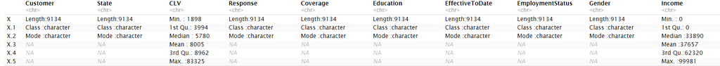

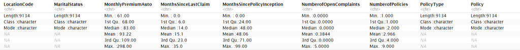

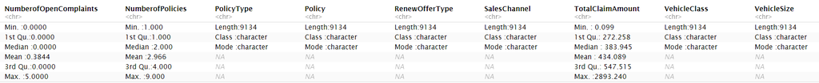

### IMPORTANT INTUITIONS FROM EXPLORARTORY DATA ANALYSIS

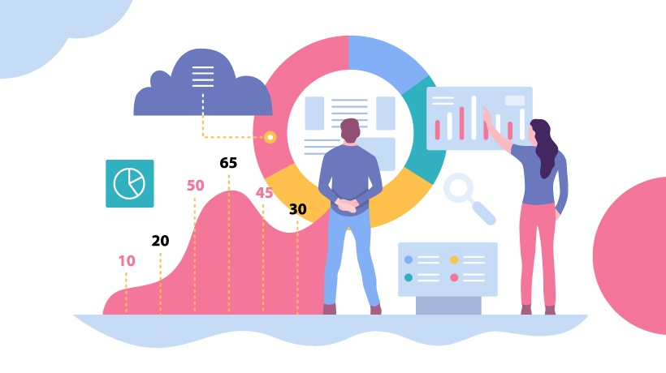

The target variable is Customer Lifetime Value and the first exploration was done of that variable and there we observed that:

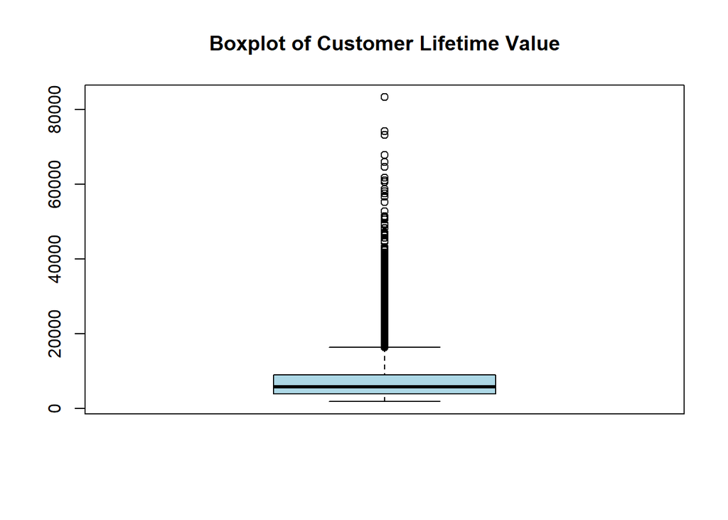

There is a significant amount of outliers for Customer Lifetime Value.

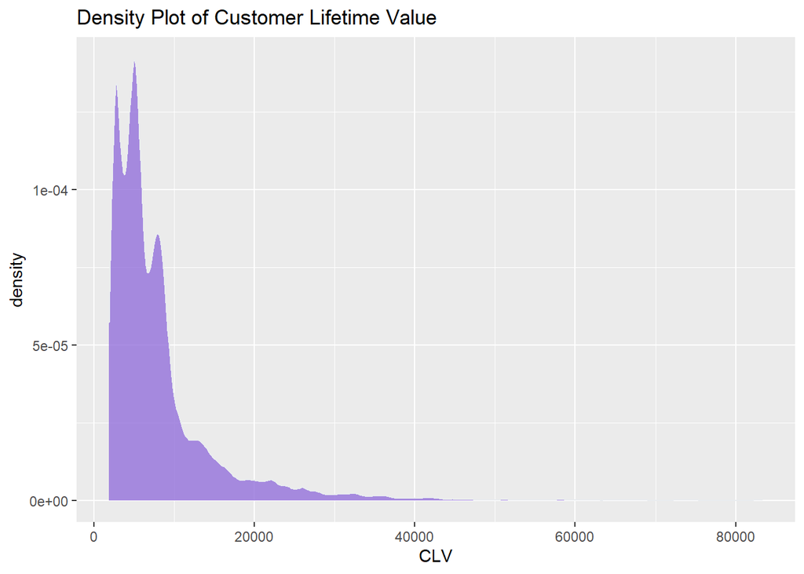

Customer Lifetime Value is right skewed, i.e, as Customer Lifetime Value increases number of customers reduces.

Next we analysed the correlation of target variable with other continuous independent variables.

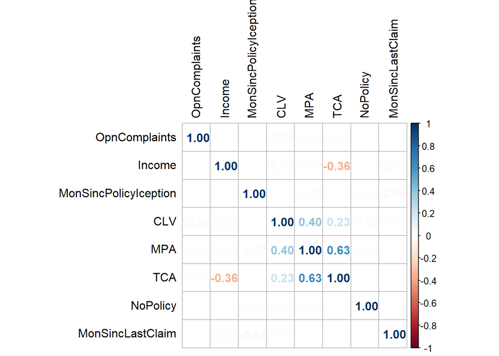

Customer Lifetime Value (CLV) shows highest positive correlations with Monthly Premiums and Total Claim Amount.

On the basis of this observation we explored the correlated variables and verified it’s relationship with target variable.

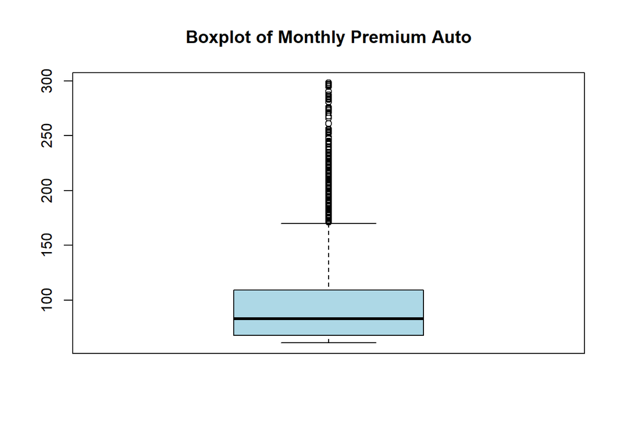

There are significant number of outliers for Monthly Premium Auto variable.

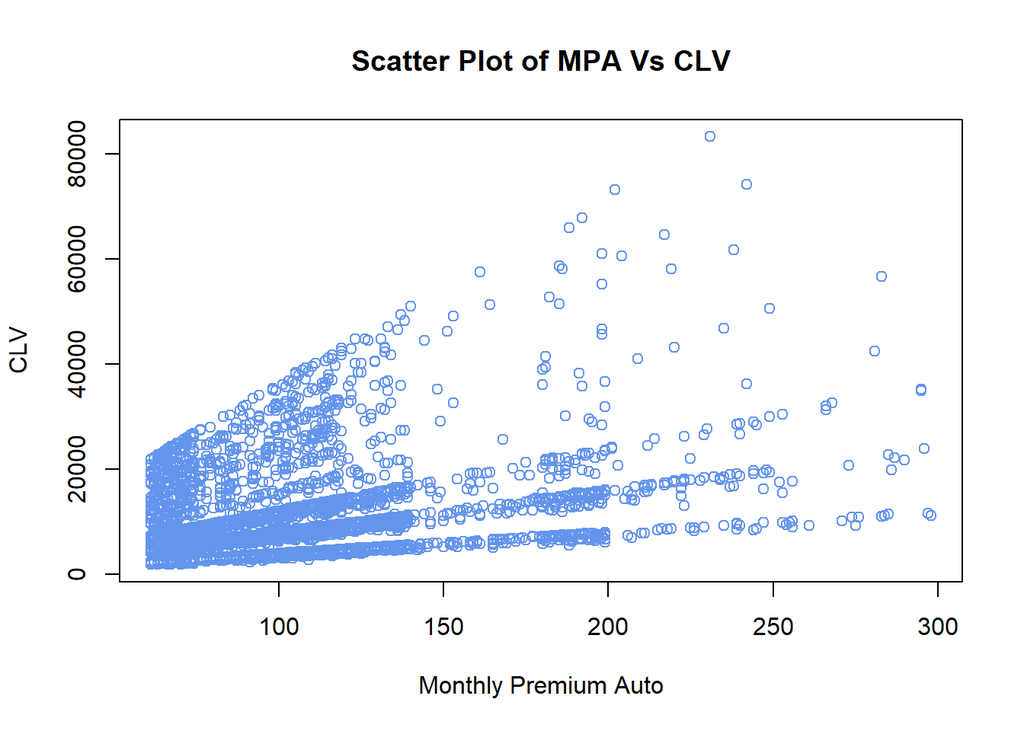

From scatter plot, it is clearly visible that on increase of MPA, CLV also increases. There is a Positive Correlation of 40 % of MPA with CLV.

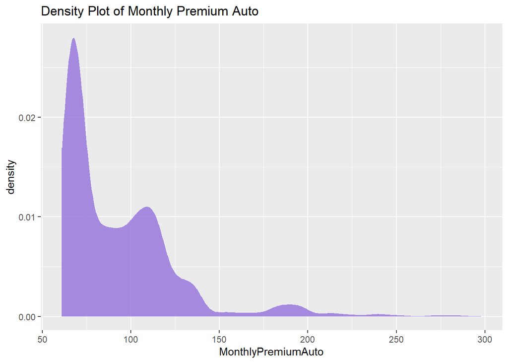

It is positvely skewed since the density is high on the left-hand side,i.e, as Monthly Premium amount increases number of customers reduces.

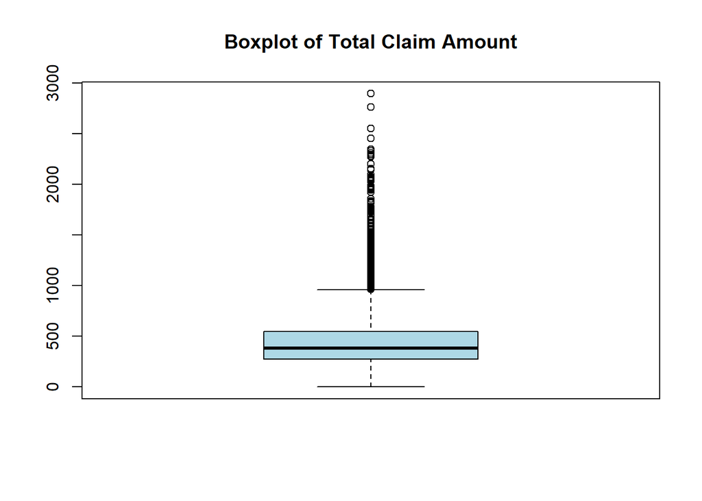

In case of Total Claim Amount there are significant number of outliers in the distribution and the outlier values are relatively high.

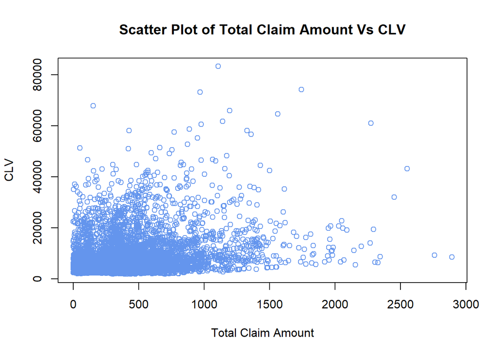

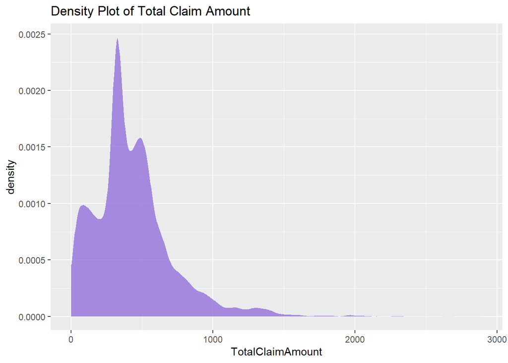

It is positvely skewed since the density is high on the left-hand side,i.e, as Total Claim Amount increases number of customers reduces.

Then our focus diverted into the various categorical variables.

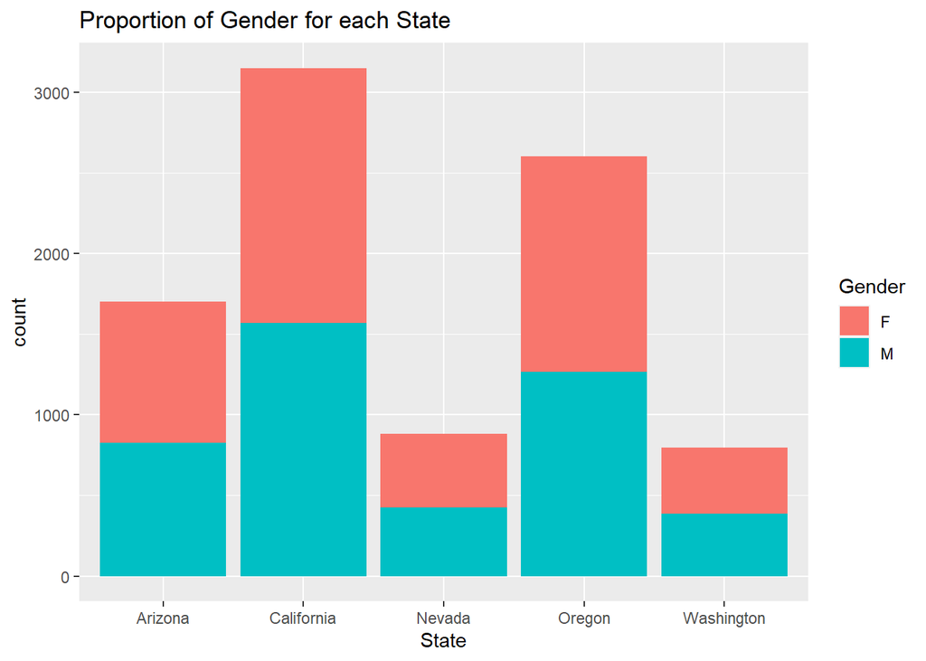

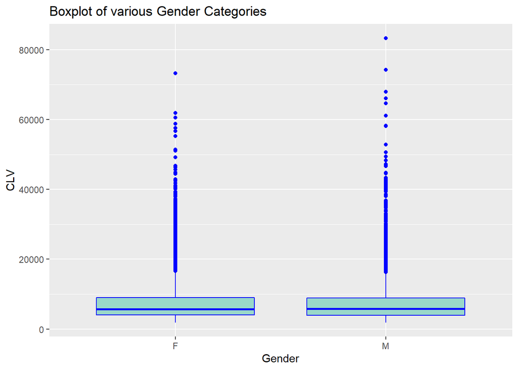

Most of the customers are from the region of California.Here we can observe that there is an equal porportion of Male and Female in all the cases and some of the male customers have highly contributed to the Customer Lifetime Value.

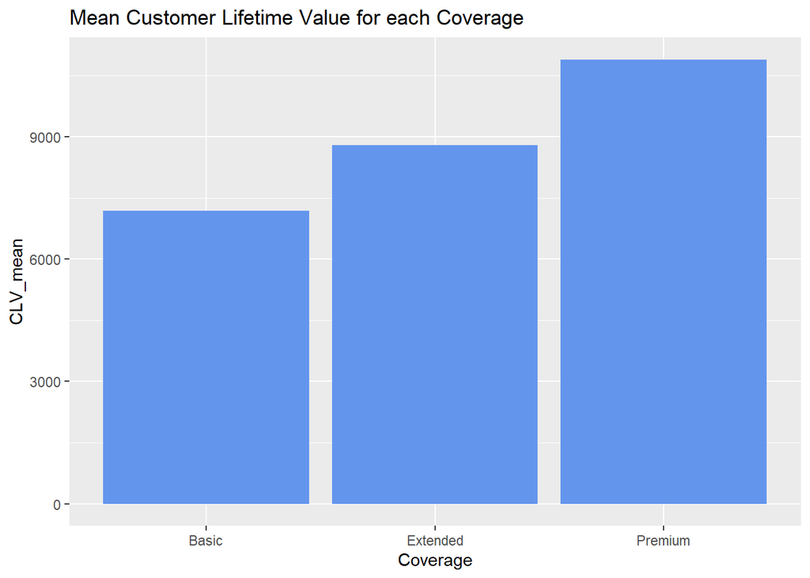

Here we can observe that the basic policy coverage chosen by the customers has the least average Customer Lifetime Value and preminum policy coverage has the highest and this is so obvious because the high profit providing customers will surely choose the best coverage and vice versa.

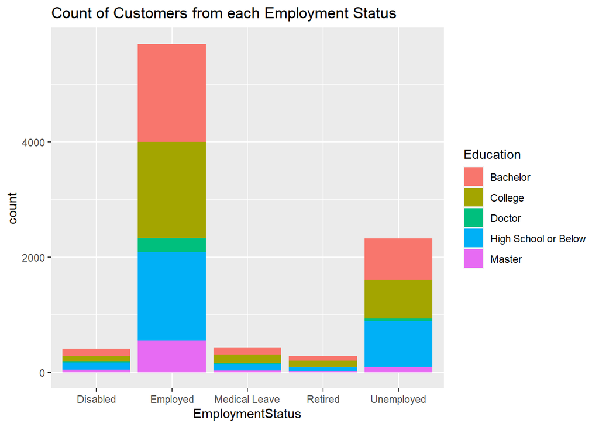

The count of employed customers is significantly high and it goes in tally with our expectation.Employed bachelors are more value to the company than others.Since the number of employed customers is high for obvious reasons, the mean Customer Lifetime Value will be high for them.

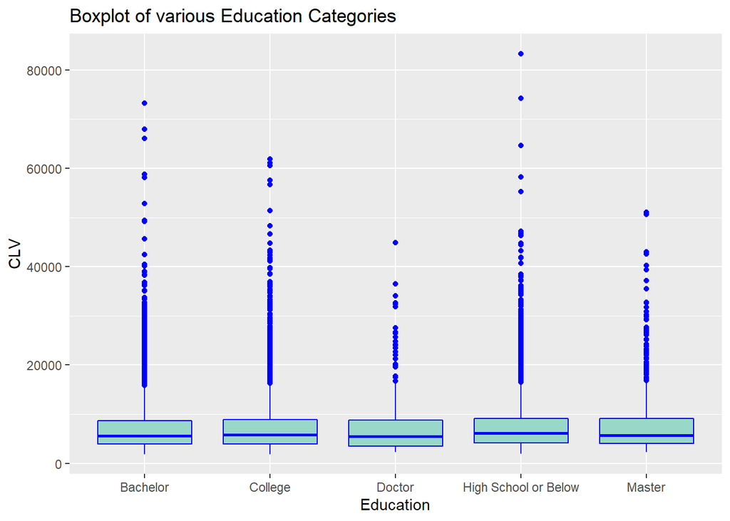

From the previous graph we can understand that, the number of Doctors and Masters are comparatively very low and number of Bachelor,High School or Below and College customers are significantly high.Eventhough the number of doctors,masters is low Mean Customer Lifetime Value for those categories doesn’t show much variation when compared with others.Some of the customers from High School or Below stands among the outliers and have extremely high CLV value.

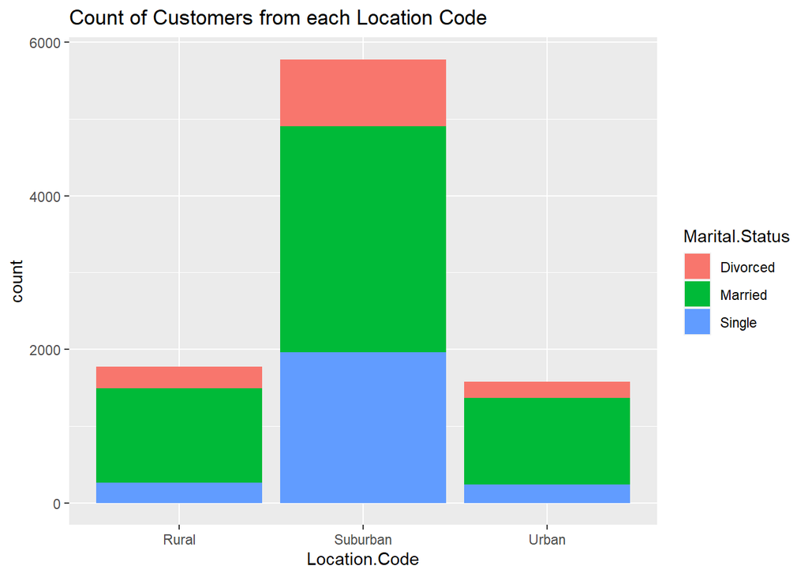

Most of the customers are from the suburban area then comes the rural followed by urban. Married surburban customers are valuable to the company.Significantly high number of customers are married followed by single customers and then divorced customers.This is because most married customers will have spouse and children and requires a more spacious vehicle for transportation so they take insurance.

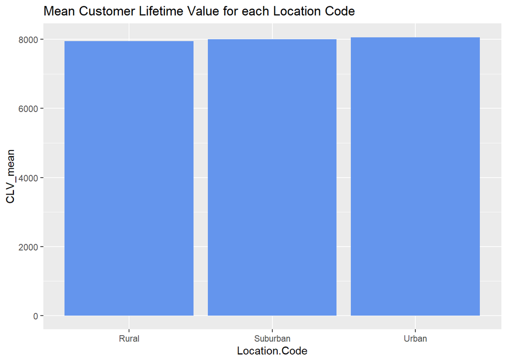

Here we can observe that the Mean Customer Lifetime Value for the urban customers is slight higher than that of other customers this maybe because urban customers tend to purchase from big corporates and they have better jobs. Urban customers are valuable to the company.

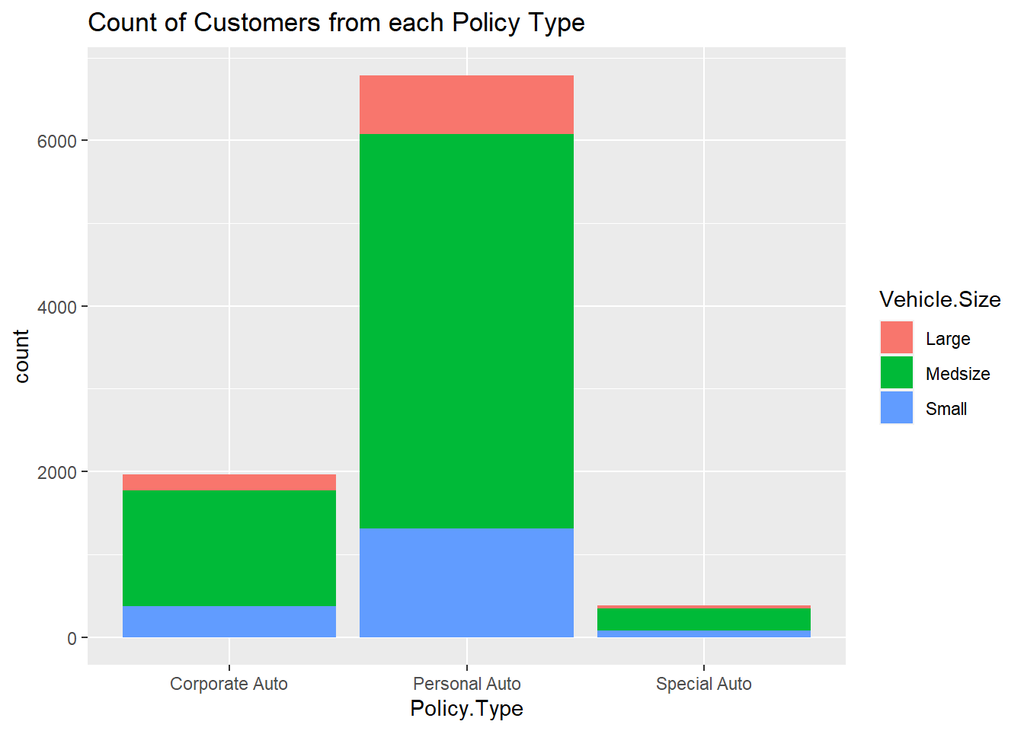

The number of customers belonging to personal auto policy type is significantly high when compared with others and number of customers belonging to special auto policy type is significantly low.Medium sized vehicle customers seeking Personal Auto Policy is valuable to the company and from this graph we clearly observe that people mostly prefer medium sized vehicles so the count for that category is significantly high, and for this reason Mean Customer Lifetime Value will be higher for medium sized vehicles.Medium sized vehicle customers seeking Personal Auto Policy is high because married customers are more in number.

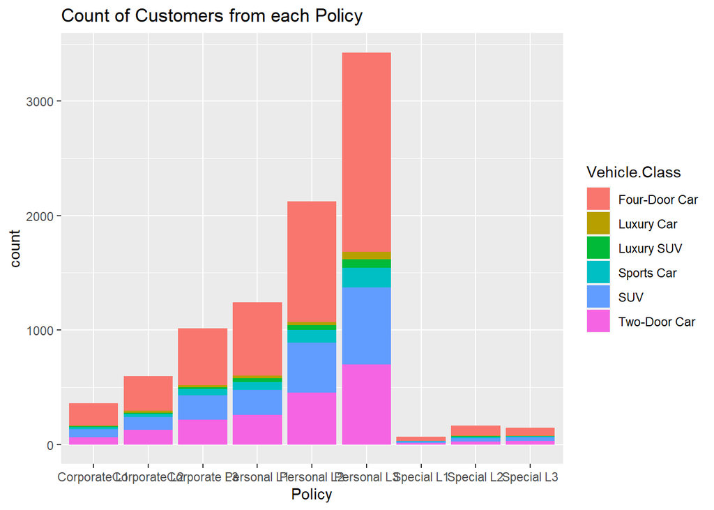

Here we case observe that the personal L3 customers are high in numbers when compare with others. Personal Policy and Four-Door Car based customers are valuable to the company.

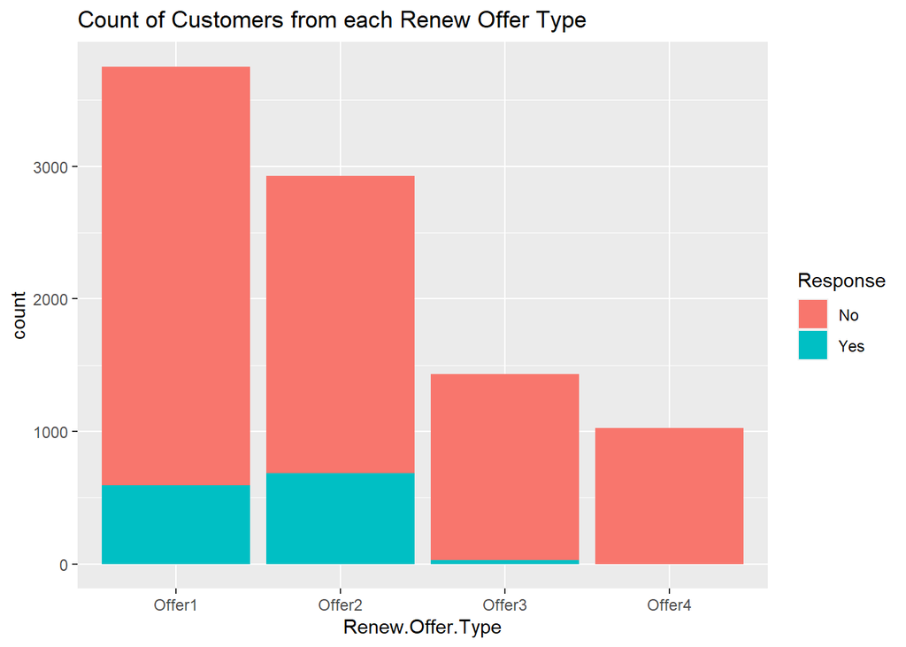

Most of the customers picked up offer 1 class renewal type because it provides maximum benefits to the customers followed by offer 2 , offer 3 and so on, from this we can conclude that customer chooses renewal based on the benefits provided by the company and customers belonging to offer 4 class renewal type had a negative response to the policy plan.

[figure not shown]

Here we can observe that offer 1 class renewal type has the highest Mean Customer Lifetime Value, this is because they enjoy maximum benefits from the company and is obliged to increase the profit of the company.On a different perspective we can say that, the customer who is favouring the company the most will be given maximum benefits, the company best possibly retains customers providing maximum profit and does not give much consideration to less profit providing customers and that is the reason why the count in those class renewal category is low. Some of offer 1 customers have very high CLV value.

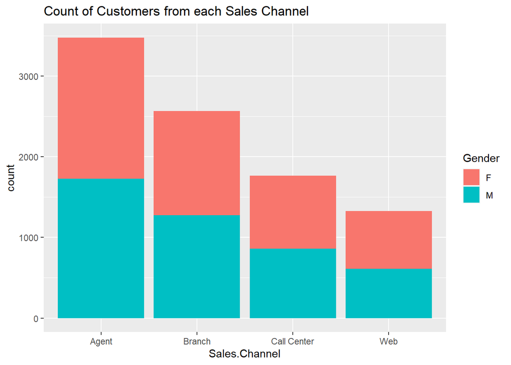

Most of the customers used Agent Sales Channel irrespective of the gender and it is followed by branch, call center and then web.

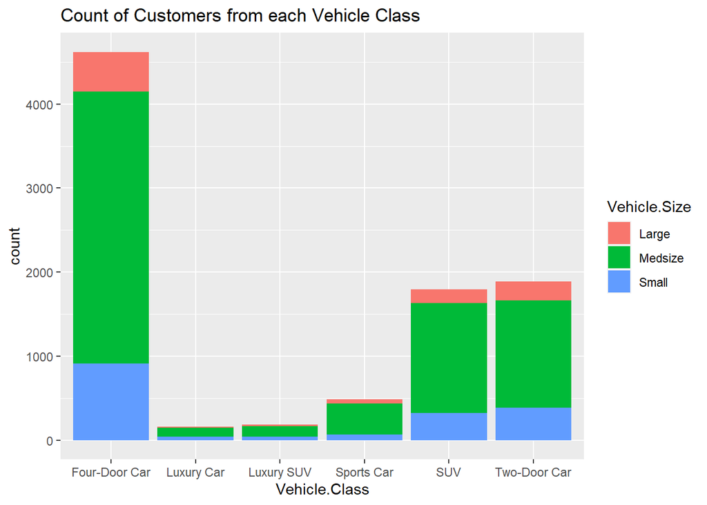

The normal Four-Door Vehicle has the maximum count when compared with other vehicle classes and luxury car have comparitively a very low count. Medium sized Four- Door Car owning Customers are valuable to the company.Altogether we can say that Medium sized, Four- Door Car and Personal policy type customers are very important to the company.

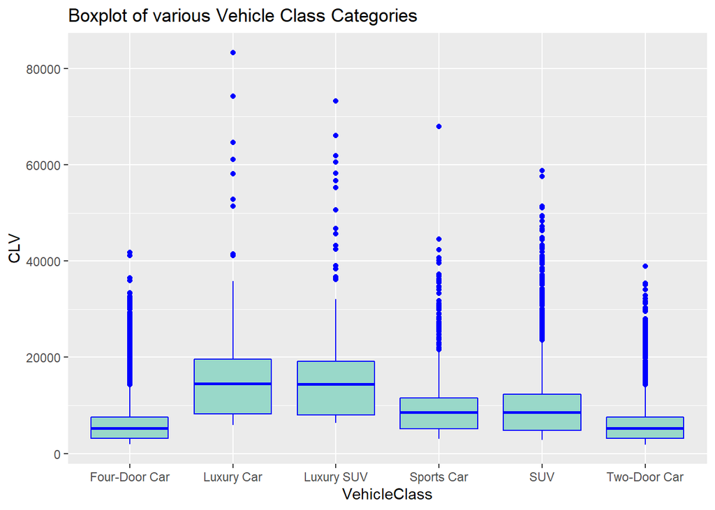

For obvious reasons we observe that some of the luxury cars and sports cars have high CLV and those customers are an asset for the company.

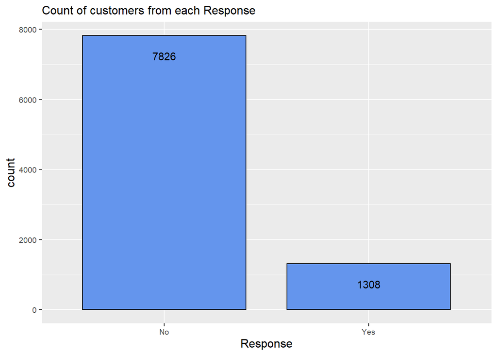

The negative response customers is quiet high than positive response customers and this means the company should focus on the improvisation of the policy plans.